# Cervus canadensis - Unsupervised Classification

First Part

Author

Affiliation

Vincent Arnaud

Université du Québec à Chicoutimi, Canada

Last Update

April 8, 2024

# Finding the optimum number of MFCCs

The first step involves the extraction of essential features from vocalizations. The core of the feature extraction process centers around the extraction of Mel-frequency cepstral coefficients (MFCCs). This holistic approach provides a parametric representation for the acoustic signals widely used in human speech processing (Davis and Mermelstein 1980). These features based on the source-filter model of human speech analysis (Fant 1960) have been successfully applied to many animal species (Mielke and Zuberbühler 2013; Spillmann et al. 2017; Oswald et al. 2022; Arnaud et al. 2023; Lakdari et al. 2024).

> “For feature extraction we relied on MFCCs, which have a number of advantages over conventional parameter-based acoustic analysis. First, as they do not rely on a researcher-driven selection of spectral features, they are able to capture information that might seem irrelevant to a researcher, despite being important in the recognition process. MFCCs do not make assumptions about the relative importance of specific spectral features, making them very suitable for cross-call and cross-species comparisons. Another advantage of MFCCs is in the standardization of the duration while still incorporating temporal features. However, not being built on the linear Hertz scale normally used to describe sounds, MFCCs are difficult to interpret; the number of coefficients extracted makes it hard to assign importance to any one of them. Ultimately, however, spectral and cepstral approaches are complementary in nature. For scientific investigations into the acoustic basis of individual, species or call recognition, spectral features potentially yield more specific knowledge, whereas MFCCs allow for fast and automatic processing.” — Mielke and Zuberbühler (2013, 480)

Whether in speech-related research or bioacoustics, finding the optimum number of MFCCs is an active research question (Hasan, Hasan, and Hossain 2021; Jensen et al. 2024). We explored various possibilities in regard to the number of MFCCs (from 12 to 40). Optimization was carried out by adapting the workflows proposed by Sainburg, Thielk, and Gentner (2020) and Jensen et al. (2024). At first, the 100 calls from the 10 individuals recorded at 12 m were analysed acoustically with the `R` package `tuneR` (Ligges et al. 2023). An anti-aliasing filter (Sueur 2018) was used before resample each call to 10,000 Hz, to remove high-frequency background noises. Their amplitude values were centered and rescaled to numeric values in the interval [-1, 1]. For each call, we extracted a matrix including, in rows, each temporal frame and in columns from 12 to 40 MFCCs, using a minimal frequency of 100 Hz, a maximal frequency of 5000 Hz, a window of 20 ms, a step of 10 ms, and no pre-emphasis. Following Muda, Begam, and Elamvazuthi (n.d.), Clink and Klinck (2021) and Jensen et al. (2024), the first coefficient, corresponding to the filterbank energy, was discarded.

A pairwise distance matrix between all calls based on multivariate dynamic time warping (DTW) of MFCCs matrices only was then computed. DTW (Sakoe and Chiba 1978) is used to determine an optimal alignment in spite of temporal irregularities or shifts between two univariate or multivariate time series. This technique was used to determine the similarity between each pair of MFCCs matrices, i.e., between each pair of calls. The output was a matrix of the normalized DTW distances between each call. DTW has been implemented using the `dtw_dismat()` function from the `R` package `IncDTW`, which parallelizes the computation of the distance matrix (Leodolter, Plant, and Brändle 2021). One of the major differences with Jensen et al. (2024)’s workflow is that we chose not to downsample the MFCCs matrices before applying multivariate DTW and therefore to maintain the originally set number of temporal frames in each of the MFCCs matrices.

Once the normalized DTW distance between each call have been determined, clustering algorithms are applicable. To determine the clusters, we proposed to use a) hierarchical Density-based spatial clustering of applications with noise (HDBSCAN, Campello, Moulavi, and Sander 2013) enhanced by an unsupervised Uniform Manifold Approximation and Projection representation (UMAP, McInnes, Healy, and Melville, n.d.) and b) HDBSCAN only.

In the first method, dimensionality reduction which transforms data from a high-dimensional space into a low-dimensional space that retains the meaningful characteristics of the original data was adopted. Indeed, UMAP was used to reduce the dimensionality of the normalized DTW distance matrix. UMAPs are powerful for exploring the structure of large datasets in bioacoustics (Sainburg, Thielk, and Gentner 2020). However, in the context of small datasets, unsupervised UMAP representations may not clarify their structure. In that regard, Thomas et al. (2022) noted that UMAP is not recommended for use on datasets with fewer than 100 observations in total. To compute unsupervised UMAP projections, we used the `umap()` function from the `uwot` `R` package with 10 neighbors, a minimal distance of 0.01 (the default value), and two dimensions for the latent space of projection. The Euclidean distance was used to find the nearest neighbors. Specifically, the hyperparameters *number of neighbors* and *minimal distance* were used to control the balance between local and global structure in the final projection (Coenen and Pearce 2019). A low value such as 10 constrains the algorithm to focus on the local structure. Following Sainburg, Thielk, and Gentner (2020), the x-y coordinates from UMAP were used as input to the unsupervised hierarchical clustering algorithm. We performed HDBSCAN with the `R` package `dbscan` (Hahsler, Piekenbrock, and Doran 2019). The only parameter required by this algorithm is the minimum number of points per cluster (`minPts`). This parameter has been set to 60% of the number of calls by individual (n=10) in all cases, which means that HDBSCAN will only form clusters that have at least 6 data points.

In a second method, the UMAP dimensionality reduction was ignored and the hierarchical clustering was performed directly with the initial normalized DTW distance matrix.

## Normalized DTW Distance Matrices

The following figures show a selection of normalized distance matrices (with a increment of 6 MFCCs) in which the calls have been grouped by individuals. These figures highlight that, while the increase from 12 to 24 MFCCs appears to enhance the quality of the clustering, the boost in performance from 36 to 40 MFCCs doesn’t seem too wide.

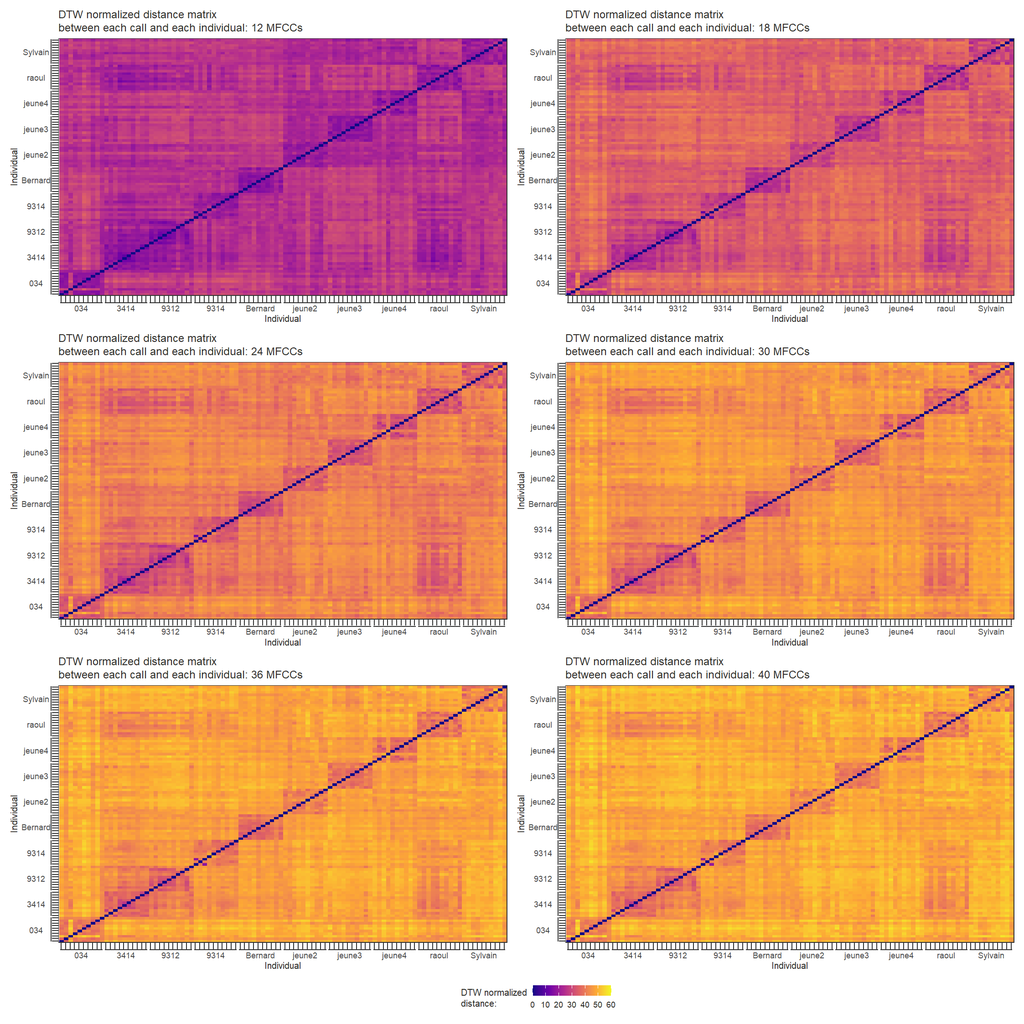

## Cluster Quality Metrics

For each number of MFCCs, four metrics were implemented for measuring agreement between clustering results and ground-truth classification: Adjusted Rand Index (ARI), Normalized Mutual Information (NMI), Normalized information distance (NID) and V-measure. ARI (Hubert and Arabie 1985), NMI (Bezdek 1974) and NID (Vinh, Epps, and Bailey 2009) scores were computed using the `R` package `aricode` (Chiquet, Rigaill, and Sundqvist 2023). Random labeling has an ARI score close to 0, whereas 1 indicates a perfect match between two clustering. NMI score estimates the degree of information provided by the clustering results with respect to the ground-truth classification. A higher value reflects better clustering quality. NID score is considered as a reference metric for validating cluster quality (Vinh, Epps, and Bailey 2009). A low NID value indicates better clustering results. Homogeneity, completeness, and V-measure are related metrics based on conditional entropy (Rosenberg and Hirschberg 2007). Homogeneity evaluates the degree to which automatically defined clusters contain only observations belonging to a single ground-truth class. Completeness measures the extent to which observations belonging to the same ground-truth class are elements of the same cluster. V-measure is the harmonic mean between homogeneity and completeness. V-measure was computed using the `R` package `clevr` (Marchant and Steorts 2023). NMI, NID and V-measure scores all range from 0 to 1.

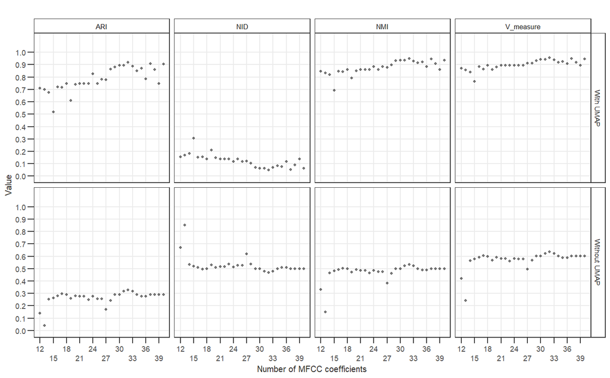

In order to find the minimum (for NID) or maximum for the three other metrics, we did not rely on the raw results. A Loess regression (Locally Estimated Scatterplot Smoothing) was used as a smoother instead and the minimum or the maximum of the regression curve was chosen (Arnaud et al. 2023). In a Loess regression, the fit at a specific point *x* is weighted according to the points closest to *x*. The distance at which points adjacent to *x* are considered close is controlled by the smoothing *span* parameter. If this parameter is too large, the regression curve will be too smooth, if too small, the curve will be too wiggly.

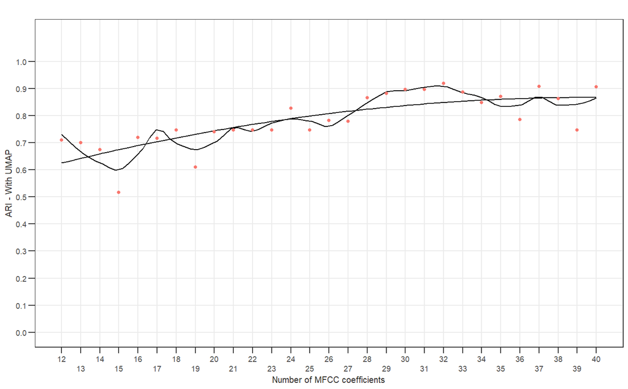

Examples of Loess regressions with extreme *span* parameter values of 0.25 and 10. As can be seen, setting the span to 0.25 leads to overfitting

In order to select the most appropriate *span* value, we chose a *span* value that optimized the fit of each Loess regression curve. To achieve it, we used the `loess.as()` function from the `R` package `fANCOVA` (Wang 2020), which automates the selection of this smoothing parameter. To select the optimal smoothing value, we chose the Adjusted Akaike Information Criterion (AICc) method, as it provides better performance on small datasets (Hurvich, Simonoff, and Tsai 1998).

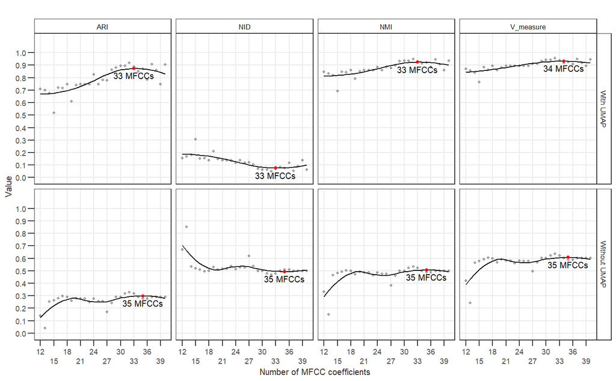

Depending on the method (with or without UMAP reduction) and the metric under consideration, the number of MFCCs corresponding to the maximum or the minimum of the regression curves varies from 33 to 35.

## Conclusion

35 MFCCs were chosen as the optimal number of MFCCs, corresponding to the statistical mode of the optimal number of MFCCs according to the four metrics explored and the two methods (with or without UMAP dimensionality reduction).

This optimization process based on two different methods confirmed a finding from Jensen et al. (2024), who observed that clustering the DTW-based distance matrix, without reducing it via UMAP, yielded poorer clustering results, regardless of the number of MFCCs and clustering quality metric under consideration. Indeed, for all four metrics assessed, the results were much less convincing if UMAP dimensionality reduction was not taken into account.

# Unsupervised Classification at seven distances: independant UMAP projections

The result of the unsupervised hierarchical classification including the 35 final features of the 100 calls recorded at the seven distances under consideration is presented below.

At first, and as explained previously, a normalized acoustic distance matrix between all sound files recorded at each of the seven distances was constructed using a multivariate DTW of the initial MFCCs matrices. The high dimensionality of the distance matrix was then reduced using a two-dimensional UMAP projection. This was used as input for unsupervised hierarchical clustering. Due to the use of stochasticity for optimization, a UMAP projection may return different results from one iteration to the next. Applying a clustering algorithm to different runs of UMAP can therefore also return different results. In order to quantify the variability induced by the stochastic nature of UMAPs, we chose to repeat this workflow 100 times and quantify the variability of the four clustering quality metrics under consideration.

The following figures show the DTW normalized distance matrices in which the calls have been grouped by individuals for each distance under consideration. Examination of the DTW normalized distance matrices reveals a gradual decline in clustering quality from 12 m to 200 m, with an almost total loss of potential clustering of the data at 400 and 800 m.

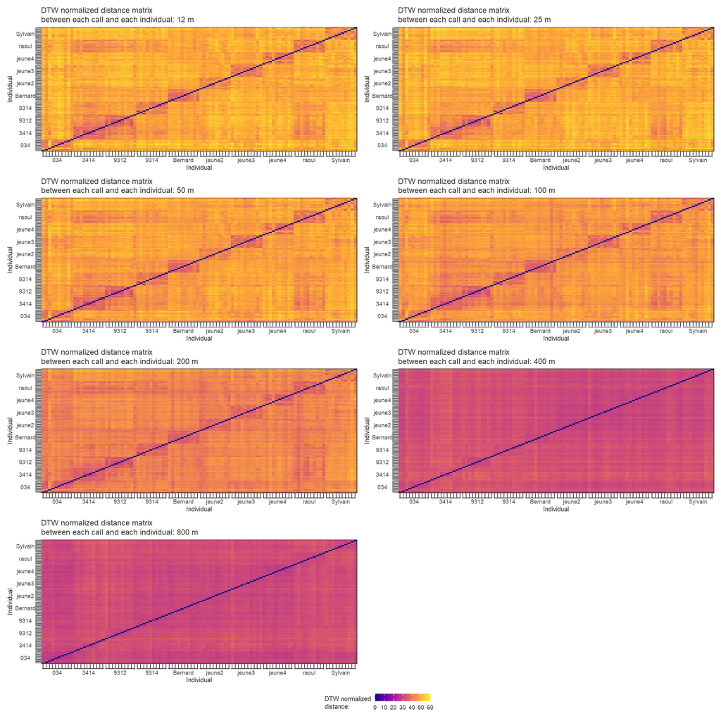

As shown in the following figure, UMAP projections at 12 m, exhibit a highly clustered pattern in terms of individuals. By applying the HDBSCAN algorithm after taking advantage of the dimensionality reduction with UMAP, as many clusters as there are individuals were regularly identified (n=10). Only a few discrepancies and noise points were identified depending on the iteration.

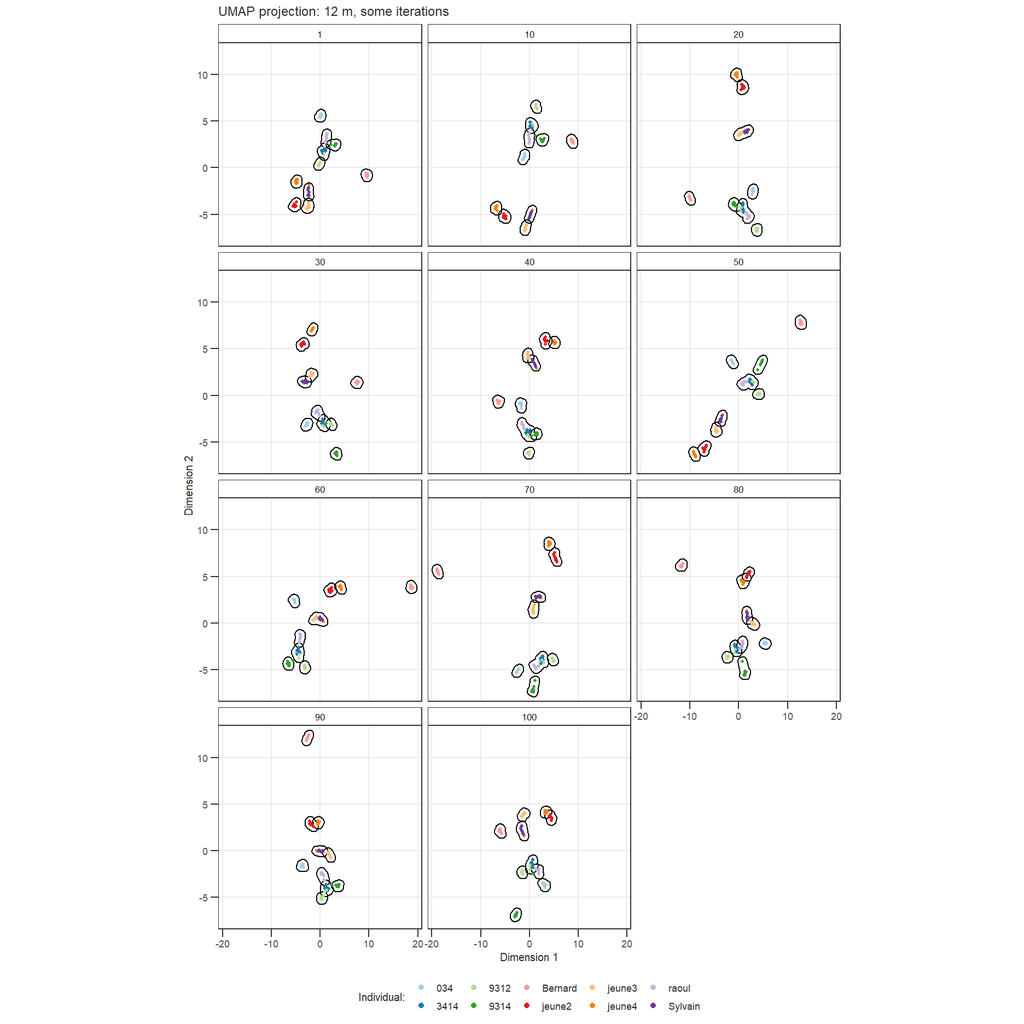

As also reflected in the values of the clustering quality metrics (see below), Canadian wapiti calls can therefore easily be assigned to distinct individuals at 12 m. This result suggests that acoustic analyses based on automatic extraction of MFCCs are effective in identifying the individual vocal signature.

Moreover, when observing the UMAP representations at each of these distances, clustering degradation is clearly visible at 400 and 800 m. On the other hand, as shown by the four metrics values, cluster quality tends to remain remarkably stable between 12 and 200 m. This result contrasts with the gradual decline in the clustering quality between 12 and 200 meters that we observed previously on the DTW normalized distance matrices.

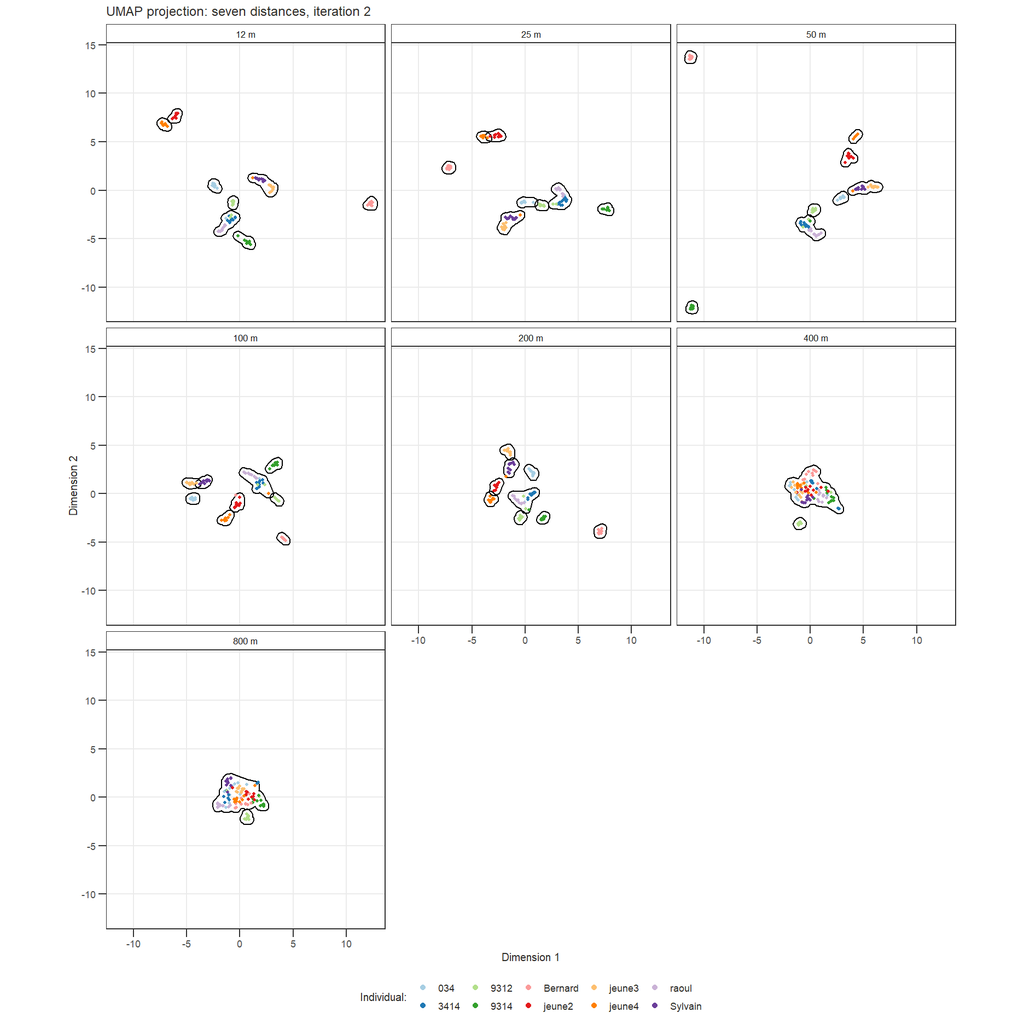

Second iteration of the UMAP projections of the 100 calls from 10 individuals recorded at the seven distances under consideration. Each point represents one call; the color encodes the true identity of the individual. The delimited areas identify the calls gathered in the clusters proposed by the unsupervised hierarchical classification.

Although a minimum of variability in terms of the number of estimated clusters or data points belonging to the same or a different group induced by the UMAP stochasticity, the values of the four clustering quality metrics appear to be very stable for each distance (low standard deviation across the 100 iterations of the UMAP projection).

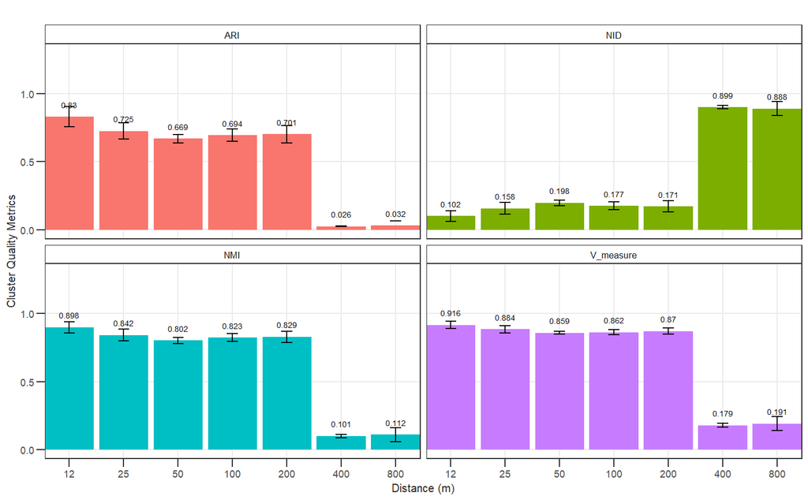

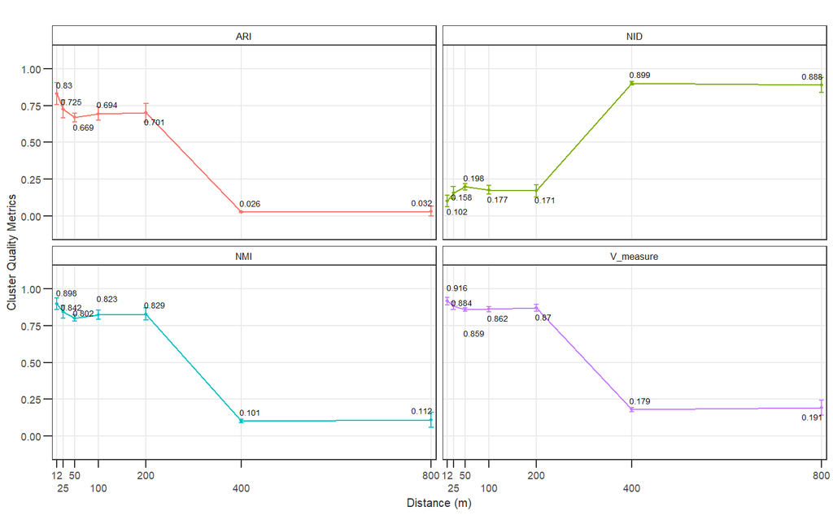

# Unsupervised Classification at seven distances: Transforming Data with UMAP

So far, each of the seven normalized acoustic distance matrices between each of the sounds recorded at each of the seven distances has been considered independently of each other. More precisely, the high dimensionality of each of these matrices has been reduced by projecting the data into a 2-dimensional latent space via UMAP. Thus, the vocalizations analyzed at each of the seven distances considered were projected into different and separate UMAP spaces.

It is also conceivable to use the 12 m distance matrix to learn a latent space by UMAP, and to transform the other 6 distance matrices to project them into this latent space. This technique exploits the UMAP’s ability to transform new data into an existing embedding space and return that transformed output. In this case, the dimensionality reduction of each of the matrices is no longer done independently of each other, but with reference to the latent space generated from vocalizations recorded at 12 m. It could be useful for understanding the trend changes in propagated data compared to 12 m data.

As above, the two-dimensional UMAP projections obtained are then used as input for unsupervised hierarchical clustering. Once again, to take into account the variability induced by the stochastic nature of UMAPs, this workflow was repeated 100 times.

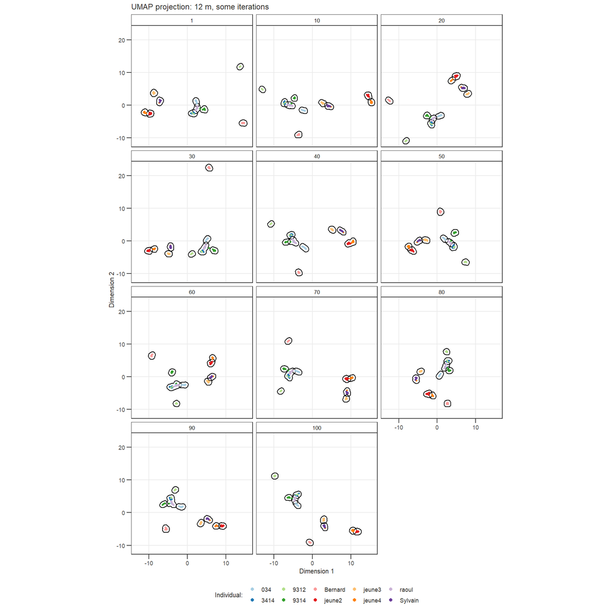

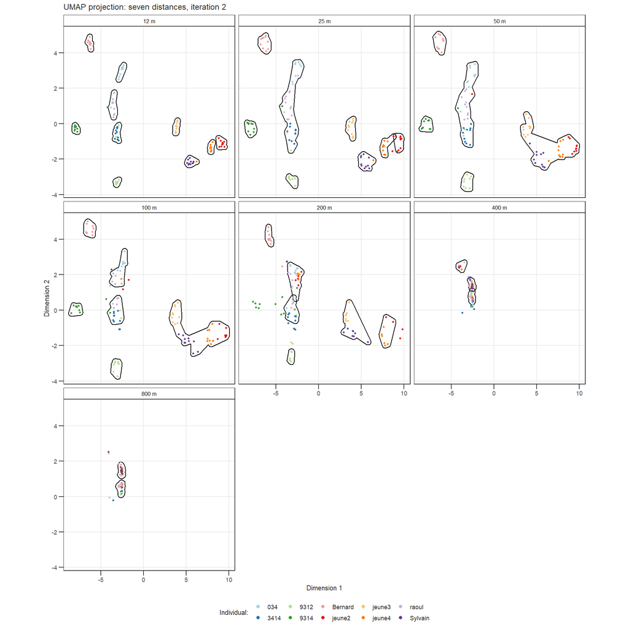

Second iteration of the UMAP projections of the 100 calls from 10 individuals recorded at the seven distances under consideration. Each point represents one call; the color encodes the true identity of the individual. The delimited areas identify the calls gathered in the clusters proposed by the unsupervised hierarchical classification.

Once again, despite the stochasticity of UMAP, the values of the four clustering quality metrics appear to be stable for each distance, even if the SDs are higher than in the previous analysis.

In contrast to the previous analysis, where the values of the four clustering quality metrics remained stable between 12 and 200 m, cluster quality tends to decline more gradually, with values remaining stable only between 25 and 100 m. This result is more consistent with the gradual decline in clustering quality between 12 and 200 m that we observed earlier on the DTW normalized distance matrices. Clustering degradation is once again particularly noticeable at 400 and 800 m.

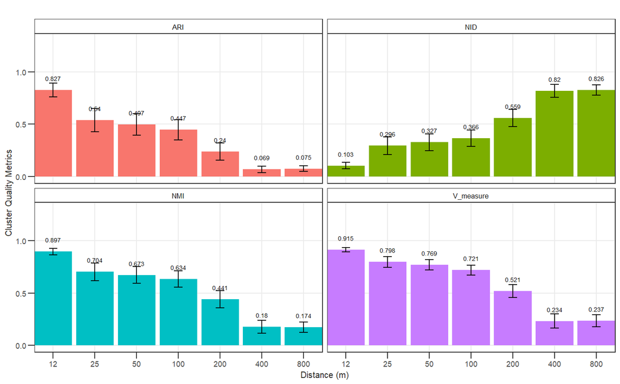

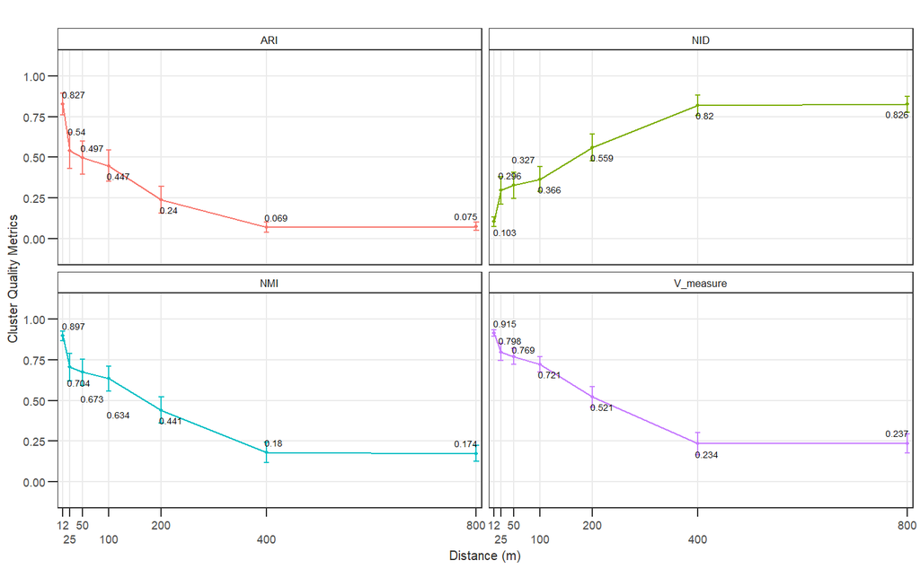

# Add-on

A UMAP projection can also help detect potential labelling error, especially by using an dynamic plot with zooming and tooltips which contain call number and individual ID. We used the package `ggiraph` which is an extension of `ggplot2` to create the following dynamic plot.

Interactive Figure: UMAP projection of the 100 calls from 10 individuals recorded at 12 m

[interactive chart not shown]

# Discussion

> The first goal of UMAP is to visualize high-dimensional data[15]. To do so, the dimension is reduced at 2 or 3. But, since UMAP is a dimension reduction method, it can be used to clarify the data, and so, to increase the results of clustering algorithms. However, this is not compulsory. Indeed, UMAP cannot completely keep the density of the data when the dimension is reduced. It can create pseudo-groups that will disturb the clustering algorithms. Indeed, an article[16] shows it on T-SNE a similar reduction of dimension. - https://www.researchgate.net/publication/352832151_Improved_Time-Series_Clustering_with_UMAP_dimension_reduction_method

https://github.com/lmcinnes/umap/issues/25

https://umap-learn.readthedocs.io/en/latest/clustering.html

https://stats.stackexchange.com/questions/263539/clustering-on-the-output-of-t-sne

# Reading notes

> “The degradation of accuracy in caller recognition from high-quality recordings to low-quality recordings was expected, but despite the large variation of microphone-caller distances the result of the low-quality recordings (72.28%) is still far above the identification success expected by chance of 10% (for 10 individuals). The different microphone-caller distances incorporate much variation based on biotic and abiotic factors. Biotic factors include background noise caused by other animal calls or by anthropogenic origin (noise of boat engines), and degradation of sounds by the vegetative structure of the location. Abiotic factors include attenuation of sounds due to the distance of the recorded call, or weather- or climate-related effects (Kirschel et al. 2009). A major limitation in applying the validated method is distance. Our result suggests that long call identification at far distances yields lower accuracy due to sound attenuation and signal degradation that results in low SNR. Nevertheless, our approach yields a remarkably high accuracy in light of the highly variable microphone-caller distances. Indeed, another study that tested individual discrimination of long calls by applying acoustic measurements of re-recorded playbacks at different distances, found possible discrimination up to 300 m (Lameira and Wich 2008). Additionally we found a tendency of a negative effect of the angle between call direction and microphone, which implies that long calls may have a directional characteristic. Our results suggest that automatic individual identification is reliable for distances up to 420 m. The limitations of this approach are sound degradation and background noise that masks the signal of interest. This raises the question whether these processes also impair the orangutans’ ability to recognize the identity of the long caller at farther distances. Evidence for improved perception of a target signal in spite of noise and degradation comes from the so-called cocktail party effect encountered in human and animal communication literature, where selective attention tunes out all but the signal of interest (Aubin and Jouventin 1998; Ebata 2003). Obviously, group living animals may face the cocktail party problem, but also heterospecific signallers may contribute to a receiver’s perception problem (Bee and Micheyl 2008). In orangutans the latter incidence is plausible: orangutans are semi-solitary and long call overlap is rare, but rainforests are quite noisy habitats (Slabbekoorn 2004).” — Spillmann et al. (2017, 117)

## References

Arnaud, Vincent, François Pellegrino, Sumir Keenan, Xavier St-Gelais, Nicolas Mathevon, Florence Levréro, and Christophe Coupé. 2023. “Improving the Workflow to Crack Small, Unbalanced, Noisy, but Genuine (SUNG) Datasets in Bioacoustics: The Case of Bonobo Calls.” *PLOS Computational Biology* 19 (4): e1010325. https://doi.org/10.1371/journal.pcbi.1010325.

Bezdek, J. C. 1974. “Numerical Taxonomy with Fuzzy Sets.” *Journal of Mathematical Biology* 1 (1): 57–71. https://doi.org/10.1007/BF02339490.

Campello, Ricardo J. G. B., Davoud Moulavi, and Joerg Sander. 2013. “Density-Based Clustering Based on Hierarchical Density Estimates.” In, edited by Jian Pei, Vincent S. Tseng, Longbing Cao, Hiroshi Motoda, and Guandong Xu, 7819:160–72. Berlin, Heidelberg: Springer.

Chiquet, Julien, Guillem Rigaill, and Martina Sundqvist. 2023. “Aricode: Efficient Computations of Standard Clustering Comparison Measures.” https://CRAN.R-project.org/package=aricode.

Clink, Dena J., and Holger Klinck. 2021. “Unsupervised Acoustic Classification of Individual Gibbon Females and the Implications for Passive Acoustic Monitoring.” Edited by Veronica Zamora-Gutierrez. *Methods in Ecology and Evolution* 12 (2): 328–41. https://doi.org/10.1111/2041-210X.13520.

Coenen, Andy, and Adam Pearce. 2019. “Understanding UMAP.” https://pair-code.github.io/understanding-umap/.

Davis, S., and P. Mermelstein. 1980. “Comparison of Parametric Representations for Monosyllabic Word Recognition in Continuously Spoken Sentences.” *IEEE Transactions on Acoustics, Speech, and Signal Processing* 28 (4): 357–66. https://doi.org/10.1109/tassp.1980.1163420.

Fant, Gunnar. 1960. *Acoustic Theory of Speech Production: With Calculations Based on x-Ray Studies of Russian Articulations*. The Hague: Mouton.

Hahsler, Michael, Matthew Piekenbrock, and Derek Doran. 2019. “Dbscan: Fast Density-Based Clustering with r.” *Journal of Statistical Software* 91 (1). https://doi.org/10.18637/jss.v091.i01.

Hasan, Md. Rakibul, Md. Mahbub Hasan, and Md Zakir Hossain. 2021. “How Many Mel-Frequency Cepstral Coefficients to Be Utilized in Speech Recognition? A Study with the Bengali Language.” *The Journal of Engineering* 2021 (12): 817–27. https://doi.org/10.1049/tje2.12082.

Hubert, Lawrence, and Phipps Arabie. 1985. “Comparing Partitions.” *Journal of Classification* 2 (1): 193–218. https://doi.org/10.1007/BF01908075.

Hurvich, Clifford M., Jeffrey S. Simonoff, and Chih-Ling Tsai. 1998. “Smoothing Parameter Selection in Nonparametric Regression Using an Improved Akaike Information Criterion.” *Journal of the Royal Statistical Society Series B: Statistical Methodology* 60 (2): 271–93. https://doi.org/10.1111/1467-9868.00125.

Jensen, Thomas Rejsenhus, Andrey Anikin, Mathias Osvath, and Stephan A. Reber. 2024. “Knowing a Fellow by Their Bellow: Acoustic Individuality in the Bellows of the American Alligator.” *Animal Behaviour* 207: 157–67. https://doi.org/10.1016/j.anbehav.2023.11.009.

Lakdari, Mohamed Walid, Abdul Hamid Ahmad, Sarab Sethi, Gabriel A. Bohn, and Dena J. Clink. 2024. “Mel-Frequency Cepstral Coefficients Outperform Embeddings from Pre-Trained Convolutional Neural Networks Under Noisy Conditions for Discrimination Tasks of Individual Gibbons.” *Ecological Informatics* 80: 102457. https://doi.org/10.1016/j.ecoinf.2023.102457.

Leodolter, Maximilian, Claudia Plant, and Norbert Brändle. 2021. “IncDTW: An r Package for Incremental Calculation of Dynamic Time Warping.” *Journal of Statistical Software* 99 (9): 1–23. https://doi.org/10.18637/jss.v099.i09.

Ligges, Uwe, Sebastian Krey, Olaf Mersmann, and Sarah Schnackenberg. 2023. “tuneR: Analysis of Music and Speech.” https://CRAN.R-project.org/package=tuneR.

Marchant, Neil, and Rebecca Steorts. 2023. “Clevr: Clustering and Link Prediction Evaluation in r.” https://CRAN.R-project.org/package=clevr.

McInnes, Leland, John Healy, and James Melville. n.d. “UMAP: Uniform Manifold Approximation and Projection for Dimension Reduction.” https://doi.org/10.48550/arXiv.1802.03426.

Mielke, Alexander, and Klaus Zuberbühler. 2013. “A Method for Automated Individual, Species and Call Type Recognition in Free-Ranging Animals.” *Animal Behaviour* 86 (2): 475–82. https://doi.org/10.1016/j.anbehav.2013.04.017.

Muda, Lindasalwa, Mumtaj Begam, and I. Elamvazuthi. n.d. “Voice Recognition Algorithms Using Mel Frequency Cepstral Coefficient (MFCC) and Dynamic Time Warping (DTW) Techniques.” https://doi.org/10.48550/arXiv.1003.4083.

Oswald, Julie N., Christine Erbe, William L. Gannon, Shyam Madhusudhana, and Jeanette A. Thomas. 2022. “Detection and Classification Methods for Animal Sounds.” In, edited by Christine Erbe and Jeanette A. Thomas, 269–317. Cham: Springer. https://doi.org/10.1007/978-3-030-97540-1_8.

Rosenberg, Andrew, and Julia Hirschberg. 2007. “EMNLP-CoNLL 2007.” In, edited by Jason Eisner, 410–20. Prague, Czech Republic: Association for Computational Linguistics. https://aclanthology.org/D07-1043.

Sainburg, Tim, Marvin Thielk, and Timothy Q. Gentner. 2020. “Finding, Visualizing, and Quantifying Latent Structure Across Diverse Animal Vocal Repertoires.” *PLOS Computational Biology* 16 (10): e1008228. https://doi.org/10.1371/journal.pcbi.1008228.

Sakoe, H., and S. Chiba. 1978. “Dynamic Programming Algorithm Optimization for Spoken Word Recognition.” *IEEE Transactions on Acoustics, Speech, and Signal Processing* 26 (1): 43–49. https://doi.org/10.1109/TASSP.1978.1163055.

Spillmann, Brigitte, Carel P. van Schaik, Tatang M. Setia, and Seyed Omid Sadjadi. 2017. “Who Shall i Say Is Calling? Validation of a Caller Recognition Procedure in Bornean Flanged Male Orangutan ( Pongo Pygmaeus Wurmbii ) Long Calls.” *Bioacoustics* 26 (2): 109–20. https://doi.org/10.1080/09524622.2016.1216802.

Sueur, Jerome. 2018. *Sound Analysis and Synthesis with r*. New York, États-Unis: Springer.

Thomas, Mara, Frants H. Jensen, Baptiste Averly, Vlad Demartsev, Marta B. Manser, Tim Sainburg, Marie A. Roch, and Ariana Strandburg-Peshkin. 2022. “A Practical Guide for Generating Unsupervised, Spectrogram-Based Latent Space Representations of Animal Vocalizations.” *Journal of Animal Ecology* 91 (8): 1567–81. https://doi.org/10.1111/1365-2656.13754.

Vinh, Nguyen Xuan, Julien Epps, and James Bailey. 2009. “Information Theoretic Measures for Clusterings Comparison: Is a Correction for Chance Necessary?” In, 1073–80. ICML ’09. New York: Association for Computing Machinery. https://doi.org/10.1145/1553374.1553511.

Wang, Xiaofeng. 2020. “fANCOVA: Nonparametric Analysis of Covariance.” https://CRAN.R-project.org/package=fANCOVA.